# Introduction to the motif package

https://jakubnowosad.com/motif/articles/v1_intro.html

Maxwell as a substitute for Nowosad, Jakub

[figure not shown]

The **`motif`** package implements ideas of the pattern-based spatial analysis in R. Its role is to describe spatial patterns of **`categorical raster data`** for any defined regular and irregular areas. Patterns are represented quantitatively using **built-in signatures based on co-occurrence matrices** but also allows for any user-defined functions. It also enables spatial analysis such as search, change detection, and clustering to be performed on spatial patterns.

# 1 Preparations

## 1.1 Load libraries

```r
# Data manipulation
library(tidyverse)
library(data.table)
library(DT)
library(gt)
library(stringr)
library(lubridate)

# Visualisation
library(ggplot2)
library(patchwork)
library(broman)  # plot_crayons()
library(extrafont)  # "Candara"
library(sf)  # map
library(motif)
library(stars)
```

## 1.2 Environment

```r
# rgb(73, 81, 112, maxColorValue = 255): "#495170"
col.1 <- "#495170"  # blue
col.2 <- "#72faa4"  # green
col.3 <- "#f7be16"  # yellow
col.4 <- "#fa8072"  # red
scale.col.1 <- c(col.1, col.4)
font.1 <- "Candara"
theme_set(theme_minimal(base_family = font.1))
options(dplyr.summarise.inform = TRUE)
```

# 2 Load DataSets

The motif package works on raster data represented by **stars objects**. It has several example datasets. This file contains a land cover data for New Guinea, with seven possible categories:

1. agriculture
2. forest
3. grassland
4. settlement
5. shrubland
6. sparse vegetation
7. water

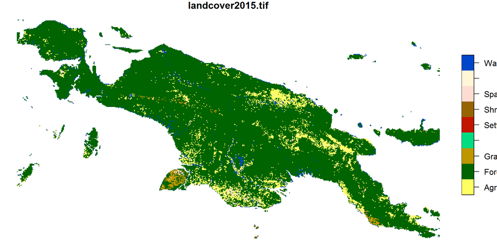

```r
landcover <- read_stars(
    system.file("raster/landcover2015.tif", package = "motif")
)
plot(landcover, downsample = 12)  # ?plot.stars
```

# 3 Signatures

## 3.1 Whole area

We can see that most of the island is covered by forest, with some agriculture and smaller areas of the other classes. It is also reasonably easy to describe these proportions (so-called composition) numerically - we just need to count cells of each category for the whole data.

We can use the **lsp_signature()** function for this. It requires a stars object as the first input and the type of a signature to calculate - “composition” in this case. There are also several additional arguments, including threshold - a share (between 0 and 1) of NA cells to allow signature calculation and normalization - decision if the output vector should be normalized.

type:  
Type of the calculated signature. It can be `"coma"` (co-occurrence matrix), `"cove"` (co-occurrence vector), `"cocoma"` (co-located co-occurrence matrix), `"cocove"` (co-located co-occurrence vector), `"wecoma"` (weighted co-occurrence matrix), `"wecove"` (weighted co-occurrence vector), `"incoma"` (integrated co-occurrence matrix), `"incove"` (integrated co-occurrence vector), `"composition"` or any function that can summarize stars objects.

```r
landcover_comp <- lsp_signature(x = landcover,
                                type = "composition",
                                threshold = 1,
                                normalization = "none")
landcover_comp
```

```
## # A tibble: 1 x 3
##      id na_prop signature
## * <int>   <dbl> <list>
## 1     1   0.666 <int [1 x 7]>
```

The output of lsp_signature(), landcover_comp, has a new class **lsp**.  
It is a tibble with three columns:

id - an id of each window (area) na_prop - share (0-1) of NA cells for each window signature - a list-column containing with calculated signatures

We can take a look at the last column:

```r
cat(class(landcover_comp))
```

```
## lsp tbl_df tbl data.frame
```

```r
landcover_comp$signature
```

```
## [[1]]
##           1       2     3    5    6     7      9
## [1,] 862001 8122776 84482 4311 2677 78555 203444
```

## 3.2 Regular local landscapes

Another approach would be to divide this large area into many regular rectangles (we refer to them as **local landscapes**) and to calculate a signature in each of them. The previously used signature, “composition” has one important flaw though. It only describes how many cells of each category we have. However, it does not distinguish an area with the left half of forest and right half of agriculture from an area with forest mixed with agriculture (think of a green-yellow checkerboard). Gladly, several more types of signatures do exist. It includes **a co-occurrence matrix (type = “coma”)**.

“coma” goes to each cell, looks at its value, looks at the values of its neighbors and **counts how many neighbors of each class our central cell has**.

```r
landcover_coma <- lsp_signature(landcover, type = "coma", window = 200)
landcover_coma
```

```
## # A tibble: 298 x 3
##       id na_prop signature
##  * <int>   <dbl> <list>
##  1     2  0.644  <int [7 x 7]>
##  2     3  0.0992 <int [7 x 7]>
##  3     4  0.145  <int [7 x 7]>
##  4     5  0.602  <int [7 x 7]>
##  5     6  0.775  <int [7 x 7]>
##  6     9  0.796  <int [7 x 7]>
##  7    38  0.255  <int [7 x 7]>
##  8    39  0      <int [7 x 7]>
##  9    40  0      <int [7 x 7]>
## 10    41  0      <int [7 x 7]>
## # ... with 288 more rows
```

```r
landcover_coma$signature[[1]]
```

```
##    1     2 3 5 6 7    9
## 1 16    24 0 0 0 0   12
## 2 24 53928 0 0 0 0  255
## 3  0     0 0 0 0 0    0
## 5  0     0 0 0 0 0    0
## 6  0     0 0 0 0 0    0
## 7  0     0 0 0 0 0    0
## 9 12   255 0 0 0 0 1644
```

## 3.3 Irregular local landscapes

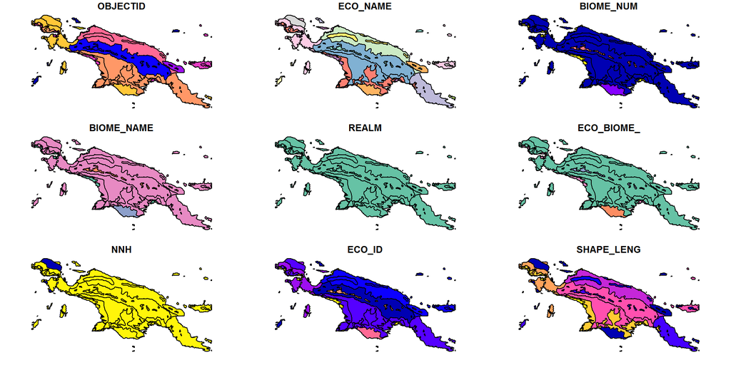

```r
ecoregions <- read_sf(
    system.file("vector/ecoregions.gpkg", package = "motif")
)
plot(ecoregions)
```

```r
landcover_coma_e <- lsp_signature(
    landcover, type = "coma", window = ecoregions["id"]
)
landcover_coma_e
```

```
## # A tibble: 22 x 3
##       id na_prop signature
##  * <int>   <dbl> <list>
##  1     1 0.114   <int [7 x 7]>
##  2     2 0.0851  <int [7 x 7]>
##  3     3 0.0377  <int [7 x 7]>
##  4     4 0.0914  <int [7 x 7]>
##  5     5 0       <int [7 x 7]>
##  6     6 0       <int [7 x 7]>
##  7     7 0.00285 <int [7 x 7]>
##  8     8 0.0720  <int [7 x 7]>
##  9     9 0.0508  <int [7 x 7]>
## 10    10 0       <int [7 x 7]>
## # ... with 12 more rows
```

```r
landcover_coma_e$signature[[1]]
```

```
##     1     2 3  5 6 7    9
## 1 662   752 0  1 0 0   13
## 2 752 70974 0  6 0 0  427
## 3   0     0 0  0 0 0    0
## 5   1     6 0 12 0 0    4
## 6   0     0 0  0 0 0    0
## 7   0     0 0  0 0 0    0
## 9  13   427 0  4 0 0 1560
```